## Assignment 5

### netid: ytian83

#### Due Thursday, October 10

The purpose of this assignment is to give you practice using tidyr commands and to review dplyr, ggplot2, and basic exploratory data analysis skills.

Turn in an HTML file and this R Markdown file after you have edited it.

### Data

The data set is in the file `ecology.csv`. It contains records about animals that were caught in traps during a many-year ecological experiment of a desert ecosystem near Portal, Arizona.

### 1

> The primary scientific objectives related to rodents. However, the traps also caught other species. Filter the data set to eliminate all observations where the `taxa` variable is not Rodent. How many cases remain?

```r
eco=eco %>%
  filter(taxa == "Rodent")

#34786 obs to 34247 obs
```

### 2

> The data set has a variable `species_id` which is a two-letter code for each species. It also has columns named `genus` and `species`. The conventional name of a species is to state both the genus and species separated by a space. Add to the data set a column named `species_name` that contains the `genus` and `species` values separated by a space. Then summarize the data to count how many rodent observations there are by species name, and arrange from most to least. How many distinct species are there? Which appears most often and how many of these individuals are in the data set?

```r
eco=eco %>%
  unite("species_name","genus","species",sep = " ")

eco %>%
  group_by(species_name) %>%
  summarise(n=n()) %>%
  arrange(desc(n))
```

```
## # A tibble: 29 x 2
##    species_name                  n
##    <chr>                     <int>
##  1 Dipodomys merriami        10596
##  2 Chaetodipus penicillatus   3123
##  3 Dipodomys ordii            3027
##  4 Chaetodipus baileyi        2891
##  5 Reithrodontomys megalotis  2609
##  6 Dipodomys spectabilis      2504
##  7 Onychomys torridus         2249
##  8 Perognathus flavus         1597
##  9 Peromyscus eremicus        1299
## 10 Neotoma albigula           1252
## # ... with 19 more rows
```

```r
##29 distinct species
##Dipodomys merriami appears most
```

### 3

> Data was collected over many years and in many plots. Make a table with one row for each plot and one column for each year with values equal to the count of the number of rodent observations collected in each plot each year with zeros where appropriate. (Use `select()`, followed by `group_by()` and `summarize()` or `count()` followed by `spread()`.)

```r
eco %>%
  select(year,plot_id)%>%
  group_by(plot_id,year)%>%
  summarise(n=n())%>%
  spread(key=year,value=n)
```

```
## # A tibble: 24 x 27
## # Groups:   plot_id [24]
##    plot_id `1977` `1978` `1979` `1980` `1981` `1982` `1983` `1984` `1985`
##      <dbl>  <int>  <int>  <int>  <int>  <int>  <int>  <int>  <int>  <int>
##  1       1     22     57     26     75     79    109    129     49    102
##  2       2     40     92     44     90     89    113     74     40    104
##  3       3     17     27     19     47     24     74     56     46     60
##  4       4     22     56     31    104     64    102     69     51     73
##  5       5     26     58     30     50     79    112     85     56     88
##  6       6     18     42     18     48     73     82     76     39    100
##  7       7      9      2      4      6      1     23     21      6     22
##  8       8     15     50     28     58     65     66     59     46     81
##  9       9     27     75     56     82     85     88     76     60     67
## 10      10      4     NA      4     20     11     18      8      5      9
## # ... with 14 more rows, and 17 more variables: `1986` <int>,
## #   `1987` <int>, `1988` <int>, `1989` <int>, `1990` <int>, `1991` <int>,
## #   `1992` <int>, `1993` <int>, `1994` <int>, `1995` <int>, `1996` <int>,
## #   `1997` <int>, `1998` <int>, `1999` <int>, `2000` <int>, `2001` <int>,
## #   `2002` <int>
```

### 4

> What is the mean weight of each rodent species and plot? Drop any cases with missing weight information. Display the information in a table with a row for each species and a column for each plot. Combinations without data should have the missing data symbol in the appropriate cell in this table. What are the dimensions of this table? Which species/plot has the highest average weight? The lowest?

```r
eco %>%
  select(species_name,plot_id,weight)%>%
  filter(is.na(weight)==FALSE) %>%
  group_by(species_name,plot_id)%>%
  summarise(mean_weight=mean(weight))%>%
  spread(key=plot_id, value = mean_weight)
```

```
## # A tibble: 25 x 25
## # Groups:   species_name [25]
##    species_name   `1`   `2`    `3`   `4`    `5`   `6`   `7`   `8`   `9`
##    <chr>        <dbl> <dbl>  <dbl> <dbl>  <dbl> <dbl> <dbl> <dbl> <dbl>
##  1 Baiomys tay~   7     6     8.61  NA     7.75  NA    NA    NA    NA
##  2 Chaetodipus~  32.4  33.5  32.6   31.2  NA     31.6  30.4  29.3  31.3
##  3 Chaetodipus~  NA    NA    18.8   20    NA     NA    NA    NA    NA
##  4 Chaetodipus~  17.1  17.2  17.3   16.1  18.0   16.6  17.8  16.3  16.4
##  5 Chaetodipus~  NA    NA    NA     NA    NA     NA    NA    NA    NA
##  6 Dipodomys m~  43.0  43.4  43.6   43.0  43.0   42.1  43.1  43.4  43.2
##  7 Dipodomys o~  50.0  49.0  49.0   46.7  49.8   48.2  52.6  48.9  48.5
##  8 Dipodomys s~ 129.  123.  128.   118.  111.   114.  126.  128.  115.
##  9 Neotoma alb~ 156.  169.  158.   164.  190.   180.  170.  134.  162.
## 10 Onychomys l~  34.3  32.3  30.7   32.8  30.8   30.9  NA    29.2  31.3
## # ... with 15 more rows, and 15 more variables: `10` <dbl>, `11` <dbl>,
## #   `12` <dbl>, `13` <dbl>, `14` <dbl>, `15` <dbl>, `16` <dbl>,
## #   `17` <dbl>, `18` <dbl>, `19` <dbl>, `20` <dbl>, `21` <dbl>,
## #   `22` <dbl>, `23` <dbl>, `24` <dbl>
```

```r
#this table is a two demention table, which contains both species name and plot id

eco %>%
  select(species_name, weight, plot_id) %>%
  group_by(species_name,plot_id) %>%
  summarise(mean=mean(weight,na.rm = TRUE))%>%
  top_n(n=1, wt=mean)%>%
  arrange(desc(mean))
```

```
## # A tibble: 26 x 3
## # Groups:   species_name [25]
##    species_name           plot_id  mean
##    <chr>                    <dbl> <dbl>
##  1 Sigmodon fulviventer        23 199
##  2 Neotoma albigula             5 190.
##  3 Dipodomys spectabilis       16 135
##  4 Spermophilus spilosoma      14 130
##  5 Sigmodon hispidus           10 101
##  6 Sigmodon ochrognathus       13  74
##  7 Dipodomys ordii              7  52.6
##  8 Dipodomys merriami          23  45
##  9 Perognathus hispidus         1  35.3
## 10 Onychomys leucogaster       10  34.4
## # ... with 16 more rows
```

```r
#Sigmodon fulviventer   in 23   has a highest weight which is 199.000000

eco %>%
  select(species_name, weight, plot_id) %>%
  group_by(species_name,plot_id) %>%
  summarise(mean=mean(weight,na.rm = TRUE))%>%
  top_n(n=-1, wt=mean)%>%
  arrange((mean))
```

```
## # A tibble: 26 x 3
## # Groups:   species_name [25]
##    species_name               plot_id  mean
##    <chr>                        <dbl> <dbl>
##  1 Baiomys taylori                  2  6
##  2 Baiomys taylori                 20  6
##  3 Perognathus flavus              23  6.4
##  4 Reithrodontomys montanus         1  8
##  5 Reithrodontomys megalotis       22  9.29
##  6 Peromyscus leucopus             19 10
##  7 Reithrodontomys fulvescens      15 11
##  8 Reithrodontomys sp.              5 11
##  9 Chaetodipus penicillatus         4 16.1
## 10 Chaetodipus sp.                 13 18
## # ... with 16 more rows
```

```r
#Baiomys taylori in plot 2  has the lowest weight, which is 6.000000
```

### 5

> Use the wasp data from discussion. Correct the error. Then use `gather()` to rewrite the data so that there is a single column of count and a separate column for the species of wasp that was counted. Then summarize this long data to find the total number of wasps collected in traps by species. Arrange these counts in a table from highest to lowest counts.

```r
library(readxl)
wasps = read_excel("wasps-data.xlsx") %>%
  rename(date = `Date Collected`,
         block = Block,
         position = Number,
         lure = Lure,
         maculifrons = `V. Maculifrons`,
         flavopilosa = `V. Flavopilosa`,
         germanica = `V. Germanica`,
         vidua = `V. Vidua`) %>%
  mutate(date = as_date(date)) %>%
  mutate(week = as.integer(as.factor(date))) %>%
  mutate(two_mb = as.integer(str_detect(lure,"2MB"))) %>%
  mutate(aa = as.integer(str_detect(lure,"AA"))) %>%
  mutate(ib = as.integer(str_detect(lure,"IB"))) %>%
  select(date,week,everything())

wasps$position[160]=2
wasps$block[160]= "D"
```

```r
wasps1=wasps %>%
  gather(key="species", value = "count", maculifrons:vidua)

wasps1 %>%
  group_by(species)%>%
  summarise(total=sum(count))%>%
  arrange(desc(total))
```

```
## # A tibble: 4 x 2
##   species     total
##   <chr>       <dbl>
## 1 maculifrons  2852
## 2 germanica    1127
## 3 flavopilosa   100
## 4 vidua           2
```

### 6

> Make a plot that shows the number of wasps collected by species in a box and whisker plot with jittered points overlayed. Use faceting so that each week is in a different row.

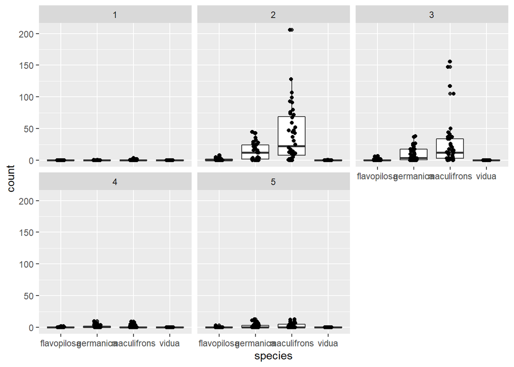

```r
wasps1%>%
  ggplot(aes(x=species,y=count))+
  geom_boxplot()+
  geom_point(position=position_jitter(height = 0,width=0.1))+
  facet_wrap(~week)
```